# shiny-tutorial

David Alberto García Estrada

2024-10-18

# Introducción

## Desarrollo web

Conceptos

[**Página web estática**](https://en.wikipedia.org/wiki/Static_web_page):

Algunas veces llamada página plana o estacionaria, es una página web que es entregada al navegador exactamente como está almacenada.

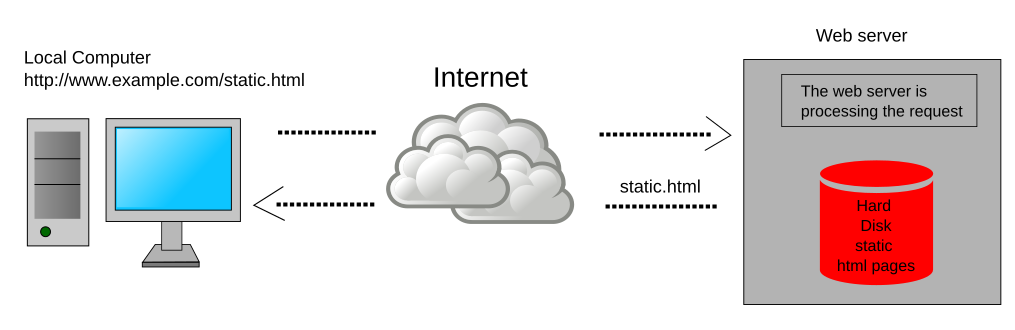

[**Página web dinámica**](https://en.wikipedia.org/wiki/Dynamic_web_page):

Es una página cuya construcción en tiempo de ejecución. Una **página web dinámica del lado del servidor** es una página cuya construcción está controlada por un servidor de aplicaciones que procesa scripts del lado del servidor.

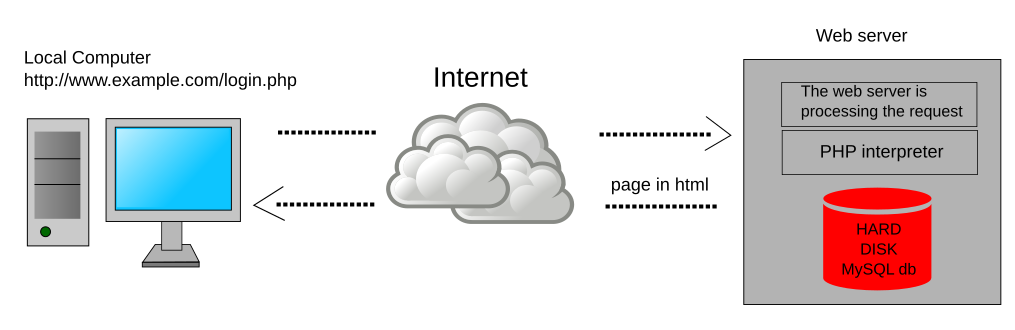

[**Aplicación web**](https://en.wikipedia.org/wiki/Web_application):

Es un programa que es almacenado en un servidor remoto y distribuye a través del internet mediante una interfaz de navegador.

[**Web framework**](https://en.wikipedia.org/wiki/Web_framework):

Tambien llamado framework para aplicaciones web, es una colección de paquetes o módulos los cuales permiten a los desarroladores escribir aplicaciones web o servicios sin tener que manejar detalles de bajo nivel como protocolos, sockets o gestión de procesos/subprocesos.

[**Desarrollo web Front-end**](https://en.wikipedia.org/wiki/Front-end_web_development):

Es el desarrollo de una interfaz gráfica o un sitio web mediante el uso de HTML, CSS, y JavaScript para que los usuarios peudan ver e interacturar con el sitio web.

[**Desarrollo web Back-end**](https://en.wikipedia.org/wiki/Frontend_and_backend):

Es el desarrollo de la [capa de acceso de datos](https://en.wikipedia.org/wiki/Data_access_layer) de un sitio web.

## ¿Qué es y para qué sirve **Shiny**?

[figure not shown]

[Shiny](https://shiny.posit.co/) es una un framwork de aplicación web para [R](https://www.r-project.org/) y [Python](https://www.python.org/) que permite generar módulos web interactivos, crear interfaces para algorítmos o bien manipular en tiempo real tablas de datos y gráficos a través de controles de HTML.

### Instalación

Para instalar la paquetería se deben usar el siguiente código

```r
install.packages("shiny")
```

## Estructura

Toda aplicación web de Shiny tendrá dos bloques de códigos de R:

- *ui*: genera una interfaz de usuario.
- *server*: contiene las intrucciones que la computadora necesita para crear la app.

La estructura de código de una app Shiny se verá de la siguiente manera:

```r
library(shiny)

ui <- fluidPage(
  Input(),
  Output()
)

server <- function(input, output){
  código de R
}

shinyApp(ui = ui, server = server)
```

En RStudio se puede generar una nueva app con este molde de código mediante los siguientes pasos:

1. Cerar un nuevo directorio y un archivo app.R que contenga una aplicación básica en un solo paso haciendo clic en *Archivo* > *Nuevo proyecto* > *Nuevo directorio* > *Shiny Web*.
2. Una vez creado el archivo **app.R**, se puede agregar la estructura estandar escribiendo `shinyapp` luego presiona la tecla `Tab`.
3. También se pueden hacer dos scripts independientes, **ui.R** y **server.R**, y ejecuar ambos en al app.R con `shinyApp(ui = ui.R, server = server.R)`.

## Interfaz de Usuario (UI)

Shiny por default usa Bootstrap (no es el método estadístico Bootstrapping). Esto es un marco de trabajo HTML, CSS y Javascript más popular para desarrollar sitios web receptivos.

Shiny fomenta la separación del código que genera la interfaz de usuario (front-end) del código que impulsa el comportamiento de la aplicación (back-end).

[figure not shown]

Existe una gran comunidad de paquetes de extensión una de ellas es awesome-shiny-extensions, mantenida por [Nan Xiao](https://github.com/nanxstats).

Para iniciar a enteder como funciona la interfaz de usuario, en un archivo `app.R` realiza lo siguiente:

```r
library(shiny)

ui <- fluidPage(
  "¡Hola mundo!"
)

server <- function(input, output, session) {

}

shinyApp(ui, server)
```

Corre la app con el botón `Run App` o en la línea de comandos de R corre la siguiente línea `shinyapp(ui, server)`.

Deberás ver algo similar a esto

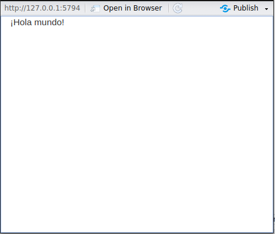

### Layouts más comunes

Vamos a mejorar la función anterior, agregando lo siguiente:

```r
library(shiny)

ui <- fluidPage(
  titlePanel("Mi app de Hola mundo"),
  "¡Hola mundo!"
)

server <- function(input, output, session) {

}

shinyApp(ui, server)
```

Ahora agrega la siguiente función `sidebarLayout`:

```r
library(shiny)

ui <- fluidPage(
  titlePanel("Mi app de Hola mundo"),
  sidebarLayout(
    sidebarPanel("Este es el sidebar panel de mi app \"Hola mundo\", y aquí van mis controles de \"INPUT\""),
    mainPanel("Este es el main panel de mi app \"Hola mundo\" y aqui van mis controles de \"OUTPUT\"")
  ),
  "¡Hola mundo!"
)

server <- function(input, output, session) {

}

shinyApp(ui, server)
```

Deberás ver algo similar a esto

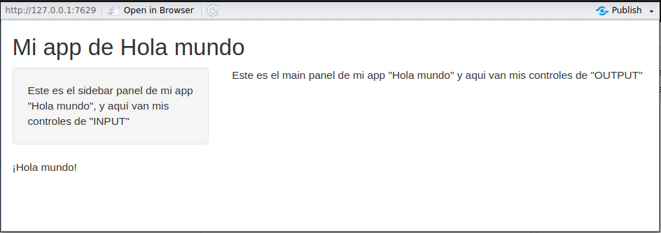

A medida que la aplicación crece en complejidad, puede resultar complejo ajustar todo en una sola página. Para este tipo de situaciónes es útil el uso de funciones como `tabPanel()` que crea la múltiples páneles, en una única página.

```r
library(shiny)

ui <- fluidPage(
  tabsetPanel(
        tabPanel("Pestaña 1", "Aqui hay un hola mundo, y se ponen los inputs"),
        tabPanel("Pestaña 2", "lo mismo que en la pestaña 1"),
        tabPanel("Pestaña 3", "Vamos a jugar con más")
    )
)

server <- function(input, output, session) {

}

shinyApp(ui, server)
```

Deberás ver algo similar a esto

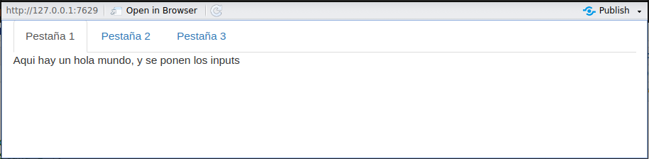

Otro layout son las listas de navegación o barras de navegación. Debido a que las pestañas se muestran horizontalmente, existe un límete fundamental en la cantidad de pestañas que se puede usar, especialmente si son títulos largos.

Las funciones `navbarPage()` y `navbarMenu()`, proporcionan dos diseños alternativos que les permite usar más pestañas con títutos más largos. La función `navlistPanel()` es similar a `tabsetPanel()`, pero en lugar de ejecutar los títulos en las pestañas horizontalmente, los muestra veerticalmente en una barra lateral.

```r
library(shiny)

ui <- fluidPage(
    navlistPanel(
        tabPanel("Pestaña 1", "Aqui hay un hola mundo, y se ponen los inputs"),
        tabPanel("Pestaña 2", "lo mismo que en la pestaña 1"),
        tabPanel("Pestaña 3", "Vamos a jugar con más")
    )
)

server <- function(input, output, session) {

}

shinyApp(ui, server)
```

Deberás ver algo similar a esto

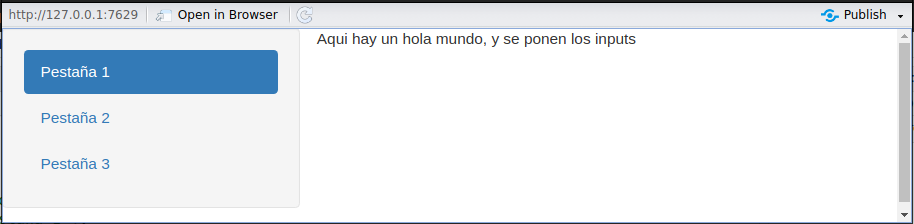

Otra alternativa

```r
library(shiny)

ui <- navbarPage(
    "ESTO ES UN TITULO DE MI APP HOLA MUNDO",
    tabPanel("Pestaña 1", "Aqui hay un hola mundo, y se ponen los inputs"),
    tabPanel("Pestaña 2", "lo mismo que en la pestaña 1"),
    tabPanel("Pestaña 3", "Vamos a jugar con más"),
    navbarMenu("Estos podrian ser subpaneles",
               tabPanel("Lo viste?? es genial", "y esto es??.."))
)

server <- function(input, output, session) {

}

shinyApp(ui, server)
```

Deberás ver algo similar a esto

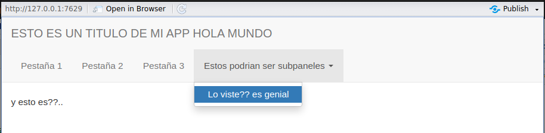

Con estas funciones en la **UI** podemos modificar los paneles:

```r
absolutePanel()
conditionalPanel()
fixedPanel()
headerPanel()
inputPanel()
mainPanel()
navlistPanel()
sidebarPanel()
tabPanel()
tabsetPanel()
titlePanel()
wellPanel()
```

Aquí hay una guia de uso de diferentes [**Layouts**](https://shiny.posit.co/r/articles/build/layout-guide/)

### Controles de Input

Estos son los controles de input más comunes:

| Función | Widget |
| --- | --- |
| actionButton() | boton de accion |
| checkboxGroupInput() | Grupo de cajas para checar |
| checkboxInput() | una sola caja para checar |
| dateInput() | Un calendario para seleccionar fecha |
| dateRangeInput() | Par de calendarios para seleccionar un rango de fecha |
| fileInput() | Asistente de control de carga de archivos |
| helpText() | Texto de ayuda que se puede agregar a un formulario de entrada |
| numericInput() | Un campo para ingresar numeros |
| radioButtons() | Un conjunto de botones de radio |
| selectInput() | Un cuadro con opciones para elegir |
| sliderInput() | Una barra lateral |
| submitButton() | Un boton de enviar |
| textInput() | Un campo para ingresar texto |

Preview de Controles de Input

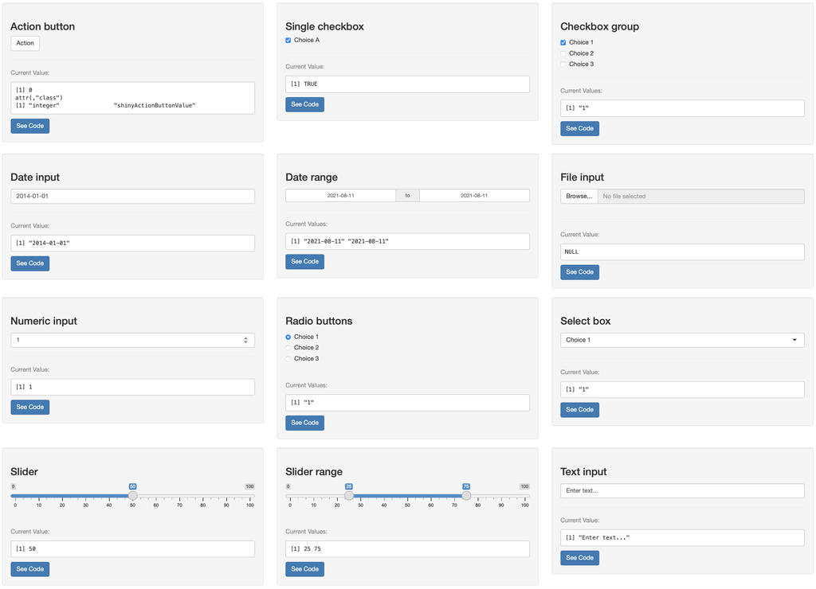

Probemos con algunos

```r
library(shiny)

ui <- fluidPage(
  titlePanel("Mi app hola mundo!"),
  sidebarLayout(
    sidebarPanel(
      numericInput("numInput", "Un input numerico:", value = 7, min = 1, max = 30)
    ),
    mainPanel(
        "este es el main panel de mi app hola mundo, y aqui van mis controles de OUTPUT"
     )
  ),
"Hola MUNDO"
)

server <- function(input, output, session) {

}
shinyApp(ui, server)
```

Deberás ver algo similar a esto

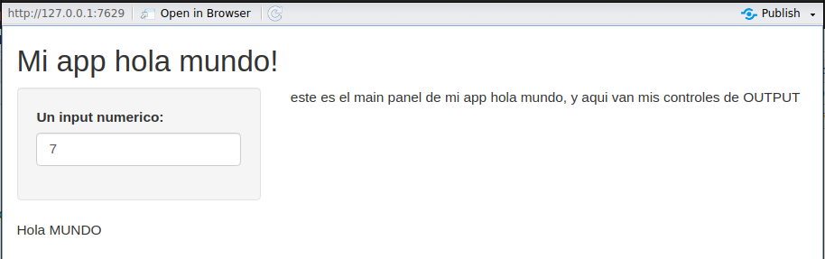

### Controles de Output

Estás son algunas funciones de control de outputs

| Función | Output |
| --- | --- |
| dataTableOutput() | una tabla interactiva |
| htmlOutput() | HTML sin formato |
| imageOutput() | imagen |
| plotOutput() | gráfico |
| tableOutput() | tabla |
| textOutput() | texto |
| uiOutput() | un elemento Shiny UI |
| verbatimTextOutput() | texto |

Los outputs tienen un efecto directo con la renderización de los resultados. En los outputs se específica el nombre o ID de las salidas y el tipo de salida que será.

```r
library(shiny)

ui <- fluidPage(
  titlePanel("Mi app hola mundo!"),
  sidebarLayout(
    sidebarPanel(
      sliderInput(inputId = "num",
                  label = "Selecciona un numero",
                  value = 14, min = 1, max = 200),
      plotOutput("identificador_de_mi_output") # <- "Aquí va el identificador del plot"
    ),
    mainPanel(
        "este es el main panel de mi app hola mundo, y aqui van mis controles de OUTPUT"
     )
  ),
"Hola MUNDO"
)

server <- function(input, output, session) {

}

shinyApp(ui, server)
```

Deberás ver algo similar a esto

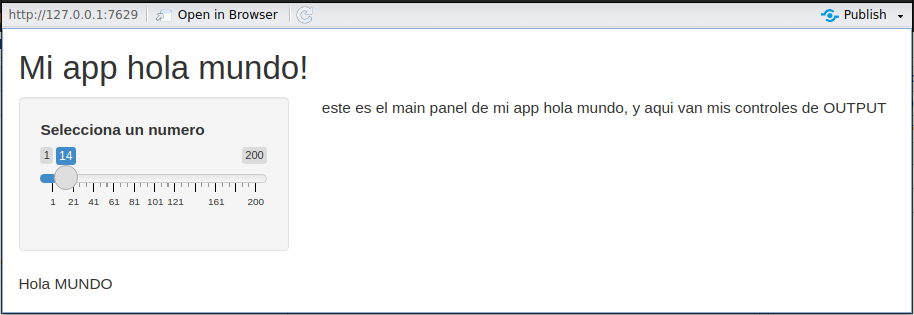

## El Servidor (Server)

El servidor permite especificar como ensamblar los inputos en los outputs.

Hay 3 reglas para escribir código en el **server**:

1. Especifica con `output$` + `ID output` cada objeto dentro de `server`.
2. Cada objeto se mostrará con un `render()`, por ejemplo, `renderPlot({})`.
3. Accesa a los valores de los inputos con `input$` + `ID input`.

| Función | Output |
| --- | --- |
| renderDataTable() | una tabla interactiva |
| renderImage() | una imagen (guardada como un enlace a un archivo funte) |
| renderPlot() | un gráfico |
| renderPrint() | un bloque de código de salida impreso |
| renderTable() | una tabla |
| renderText() | un texto |
| renderUI() | un elemento Shiny UI |

Mejoraremos la app de **Hola Mundo** añadiendo *reactividad*:

```r
library(shiny)

ui <- fluidPage(
  titlePanel("Mi app hola mundo!"),
  sidebarLayout(
    sidebarPanel(
      sliderInput(inputId = "num",
                  label = "Selecciona un numero",
                  value = 14, min = 1, max = 200)
    ),
    mainPanel(
        "este es el main panel de mi app hola mundo, y aqui van mis controles de OUTPUT",
        plotOutput("identificador_de_mi_output")
     )
  ),
"Hola MUNDO"
)

server <- function(input, output, session) {
    output$identificador_de_mi_output <- renderPlot({
        library(ggplot2)
        var_1 <- rnorm(input$num)
        var_2 <- data.frame(norma = var_1)

        ggplot(var_2, aes(x = norma)) +
          geom_density() +
          theme_classic()
    })
}

shinyApp(ui, server)
```

Deberás ver algo similar a esto

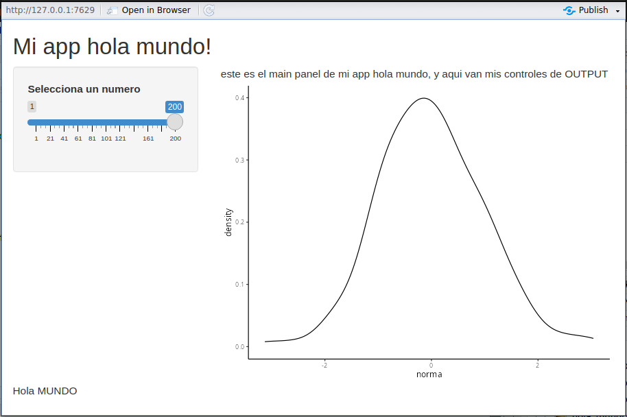

La reactividad funciona de la siguiente manera:

[figure not shown]

## Presentación Resumen

Autor: **Alejandro Reyes**

[interactive chart not shown]